# Technical Appendix

## Introduction

This is an early draft of what will become the companion Appendix to the modeling papers that we publish. Narrative text and the R code are interwoven. The computer code is also available in a public [GitHub repository](https://github.com/khanna7/cadre).

This is written in [R Markdown](http://rmarkdown.rstudio.com) to facilitate [reproducibility](https://bookdown.org/m_p_sperrin/intro_to_r_2020/projects-and-reproducibility.html). One advantage of this format is that the data sources, decisions about parameterization, and the computer code implementing these decisions all exist in one place. This makes it easier to understand the reasoning behind the decisions made, and document the data sources as I go. The document can also be automatically updated whenever the underlying code or data change.

This is my first attempt at a full-scale reproducible document; please bear with me as I figure out kinks and assess if this would be a workable format.

## Population Overview

A synthetic population consisting of 5000 agents between 18 and 64 years of age is simulated in an agent-based model (ABM) with social network structure. This simulated population is broadly representative of the 18-64 year old population of RI. The population size is deliberately kept small in the early stages to make the model more efficient in terms of computation time.

Each individual is assigned a set of demographic characteristics (age, race, sex), behavioral profiles (smoking, alcohol use), incarceration history. Feedback loops between the impacts of incarceration on smoking and alcohol use are simulated in the criminal-justice involved persons, and their social networks.

## Demographic Characteristics

### Age

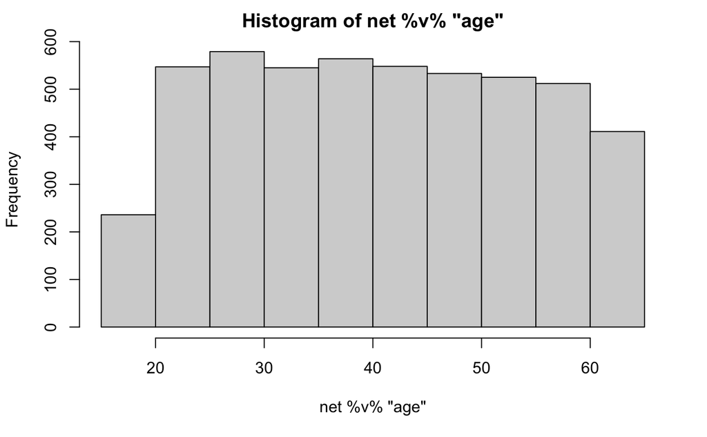

```r
age.min <- 18
age.max <- 64
age <- runif(n, age.min, age.max)
net %v% "age" <- age
hist(net %v% "age")
```

### Race

Per census data, we parameterize the population as belonging to 5 race/ethnic categories: White, Black, Hispanic, Asian, and Other.

```r
white_alone <- 71.4/100 #not Hispanic or Latino
black_alone <- 8.5/100
hispanic_alone <- 16.3/100
asian_alone <- 3.7/100
other <- 1- sum(c(white_alone, black_alone, asian_alone, hispanic_alone))

race_cats <- c("White", "Black", "Hispanic", "Asian", "Other")

race <-
  sample(x=race_cats,
       prob = c(white_alone, black_alone, hispanic_alone, asian_alone, other),
       replace = TRUE,
       size = n
       )
net %v% "race" <- race
table(net %v% "race")
table(net %v% "race")/sum(table(net %v% "race"))
```

### Sex

```r
# sex (https://www.census.gov/quickfacts/RI)
female.prop <- 51.3/100
female <- rbinom(n, 1, prob=female.prop)

net %v% "female" <- female
table(net %v% "female")
```

Per census data, the proportion of females in RI is 51.3%. We dichotomize 51.3% of our our agents as being female, and 48.7% as being male.

## Substance Use Behaviors

### Smoking

```r
smoking.prev <- 0.13
net %v% "smoking.prob" <- smoking.prev
smoking.prob <- net %v% "smoking.prob"
```

Per the [CDC](https://www.cdc.gov/tobacco/data_statistics/fact_sheets/adult_data/cig_smoking/index.htm), the national prevalence of current smokers in the US is 13%. ( The CDC defines “a current smoker” as someone who “who reported smoking at least 100 cigarettes during their lifetime and who, at the time they participated in a survey about this topic, reported smoking every day or some days.”)

The [CDC](https://www.cdc.gov/tobacco/data_statistics/fact_sheets/adult_data/cig_smoking/index.htm) also stratifies the national smoking rates by age, sex, and race/ethnicity. There is also a geographic prevalence of smoking (about 10% in the northeastern US), that is not stratified by demographic variables.

### Alcohol Use

We classify alcohol use behaviors in one of four categories, defined as in a previous pair of by frequency of use, as per Apostolopoulos et al. (2018b); Apostolopoulos et al. (2018a). The four categories are: “abstainers,” “occassional users,” “regular users,” “persons with high-risk use or Alcohol Use Disorder (AUD).”

Perhaps we should update these proportions using our updated [analysis](https://github.com/khanna7/cadre/blob/master/Alcohol%20and%20Incarceration%20Coding%20Problem%205:12.Rmd) from Yurui?

To parameterize the distribution of persons in each of these categories, data from the National Comorbidity Survey Replication, as published in Kalaydjian et al. (2009), where:

```
* (A) 91.7% (SE=0.9) reported >1 sip of alcohol at some time in their life,
* (B) 72.9% (1.3) reported using alcohol regularly at some time in their life
* (C) 13.2% (0.6) met criteria for alcohol abuse at some time in their life, and
* (D) 5.4% (0.3) met criteria for alcohol dependence at some time in their life.
```

Thus, the proportion of abstainers is $1-A = 8.3%$. For simplicity, Category B above is taken to be “occasional users,” Category C as “regular users.” Category D as High-Risk/AUD = 100-(A+B+C) = 5.6%, which is almost the same as D reported by Kalaydjian et al. (2009).

## Initiatializing the Incarceration Process in the Model

Incarceration fuctions by defining two locations: a “correctional setting” (CS), and a “home” setting. Per Macmadu et al. (2021), the 2-week incarceration probability for RI persons is 1.7%. We thus initialize the model with 1.7% of persons in the correctional setting.

## Modeling Feedback between Incarceration and Substance Use

### Modeling Impact of Incarceration on Smoking

See D. de Andrade and Kinner (2017) for “Systematic review of health and behavioural outcomes of smoking cessation interventions in prisons.”

### Modeling Feedback between Incarceration and Alcohol Use

#### Persons with AUD who have incarceration history

As with smoking, pre-incarceration behaviors related to alcohol use may be altered upon release. Using data from the National Epidemiologic Survey on Alcohol and Related Conditions-III, for persons with alcohol use disorder, Tsai and Gu (2019) report an odds ratio of 0.75 (95% CI: 0.63, 0.89) among persons with incarceration history to persons without. We can combine this information with the proportion of persons with AUD in section on Alcohol Use above, where the proportion of persons suffering from AUD was computed to be 5.6%.

Table 2 in Tsai and Gu (2019) reports that percent of persons with AUD without incarceration history is 7550/8183 (we call this $p_1$) and proportion of persons with AUD with incarceration history is 2388/2670 (call this $p_2$). Then, the OR can be computed as $(p_2/1-p_2)/(p_1/1-p_1) = 0.71$ (though Tsai and Gu (2019) gives this OR as 0.75). We take the published value of 0.75, set $p_1=5.6$% as stated in Alcohol Use, and solve for to get $p_2 = 4.3$%. Thus, proportion of proportion of persons with AUD who have incarceration history is 4.3%.

#### Persons with incarceration history who have AUD

(__ I might email the authors and ask if they can tell me the % of persons reporting AUD before incarceration and after release__).

See D. D. Andrade et al. (2018) for additional data on incarceration, recidivism, and drug and alcohol interventions.

## Next Steps

- Stratify current smokers by age, race, and sex
- Incarceration: Sentence duration and recidivism probability
- Stratify impact of incarceration on smoking/alcohol use by race/ethnicity?

## Save image

save.image(file=“initialized-population.RData”)

Andrade, Dominique de, and Stuart A. Kinner. 2017. “Systematic Review of Health and Behavioural Outcomes of Smoking Cessation Interventions in Prisons.” *Tobacco Control* 26: 495–501. https://doi.org/10.1136/tobaccocontrol-2016-053297.

Andrade, Dominique De, Jessica Ritchie, Michael Rowlands, Emily Mann, and Leanne Hides. 2018. “Substance Use and Recidivism Outcomes for Prison-Based Drug and Alcohol Interventions.” *Epidemiologic Reviews* 40 (June): 121–33. https://doi.org/10.1093/epirev/mxy004.

Apostolopoulos, Yorghos, Michael K. Lemke, Adam E. Barry, and Kristen Hassmiller Lich. 2018a. “Moving Alcohol Prevention Research Forward—Part i: Introducing a Complex Systems Paradigm.” *Addiction* 113: 353–62. https://doi.org/10.1111/add.13955.

———. 2018b. “Moving Alcohol Prevention Research Forward—Part II: New Directions Grounded in Community-Based System Dynamics Modeling.” *Addiction* 113: 363–71. https://doi.org/10.1111/add.13953.

Bailey, Zinzi D., Cassandra Okechukwu, Ichiro Kawachi, and David R. Williams. 2015. “Incarceration and Current Tobacco Smoking Among Black and Caribbean Black Americans in the National Survey of American Life.” *American Journal of Public Health* 105: 2275–82. https://doi.org/10.2105/AJPH.2015.302772.

Chamberlain, Adam, Sylviah Nyamu, Jenerius Aminawung, Emily A. Wang, Shira Shavit, and Aaron D. Fox. 2019. “Illicit Substance Use After Release from Prison Among Formerly Incarcerated Primary Care Patients: A Cross-Sectional Study.” *Addiction Science & Clinical Practice* 14 (February): 7. https://doi.org/10.1186/s13722-019-0136-6.

Kalaydjian, Amanda, Joel Swendsen, Wai Tat Chiu, Lisa Dierker, Louisa Degenhardt, Meyer Glantz, Kathleen R. Merikangas, Nancy Sampson, and Ronald Kessler. 2009. “Sociodemographic Predictors of Transitions Across Stages of Alcohol Use, Disorders, and Remission in the National Comorbidity Survey Replication.” *Comprehensive Psychiatry* 50 (July): 299–306. https://doi.org/10.1016/j.comppsych.2008.09.012.

Macmadu, Alexandria, Joëlla W. Adams, S. E. Bessey, Lauren Brinkley-Rubinstein, Rosemarie A. Martin, Jennifer G. Clarke, Traci C. Green, Josiah D. Rich, and Brandon D. L. Marshall. 2021. “Optimizing the Impact of Medications for Opioid Use Disorder at Release from Prison and Jail Settings: A Microsimulation Modeling Study.” *International Journal of Drug Policy* 91 (May). https://doi.org/10.1016/j.drugpo.2020.102841.

Tsai, Jack, and Xian Gu. 2019. “Utilization of Addiction Treatment Among u.s. Adults with History of Incarceration and Substance Use Disorders.” *Addiction Science & Clinical Practice* 14 (March): 9. https://doi.org/10.1186/s13722-019-0138-4.